# Machine Learning - Project Part I

Adesh Ghadge

8/18/2018

### Part 1: Regression

```r
dat<-read.csv(file=paste(dataPath,"slice_localization_data.csv",sep="/"))
```

### Data Exploration

```r
#Remove id and target variable
pred<-dat[,c(-1,-386)]

#Set target variable
Y<-dat[,386]

head(colnames(pred))
```

```
## [1] "value0" "value1" "value2" "value3" "value4" "value5"
```

```r
tail(colnames(pred))
```

```
## [1] "value378" "value379" "value380" "value381" "value382" "value383"
```

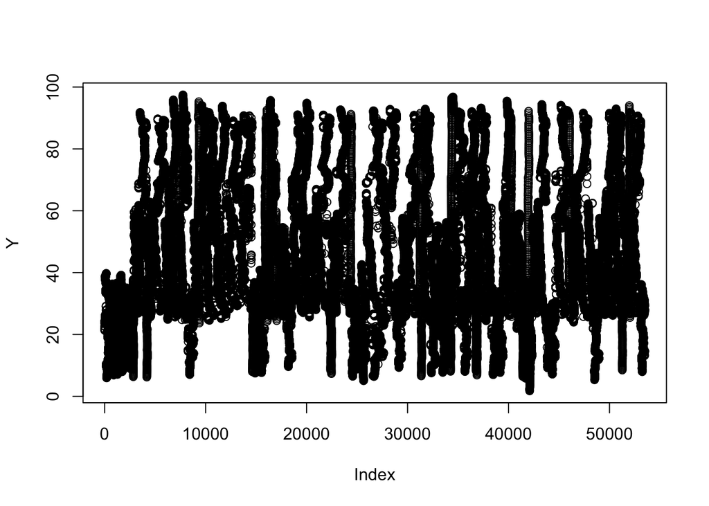

```r
plot(Y)
```

**We see that Y has high variance.**

```r
summary(Y)
```

```
##    Min. 1st Qu.  Median    Mean 3rd Qu.    Max.
##   1.739  29.892  43.988  47.028  63.735  97.489
```

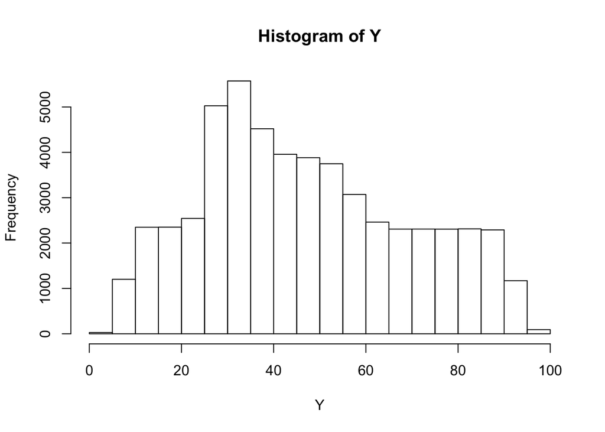

```r
hist(Y)
```

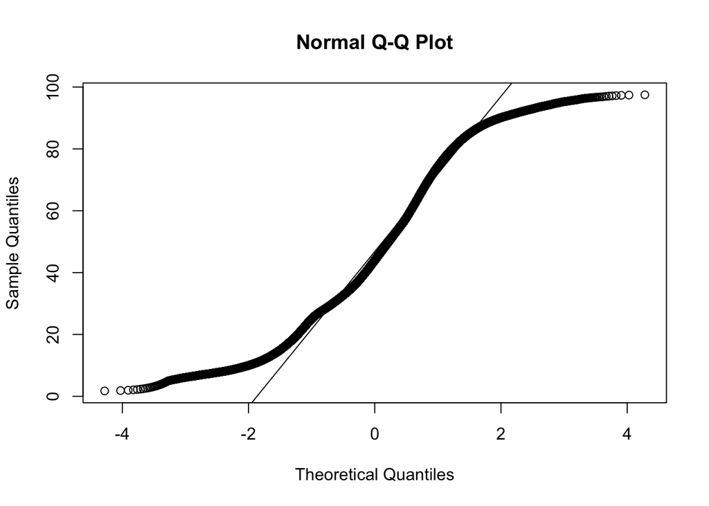

```r
qqnorm(Y)
qqline(Y)
```

**The QQ plot diverges quite a bit at the tails. This data will probably fail normality test.**

**Let us perform KS Test to check for normality**

```r
ks.test(unique(Y), "pnorm", mean(Y), sd(Y))
```

```
##
##  One-sample Kolmogorov-Smirnov test
##
## data:  unique(Y)
## D = 0.065371, p-value < 2.2e-16
## alternative hypothesis: two-sided
```

**The p-value is less 0.05 hence the data fails the test. It is not normally distributed.**

### Linear Regression

```r
#Remove id column
data.model <- dat[, -1]

lin.model <- lm(reference ~ ., data = data.model)
lin.model.sm <- summary(lin.model)
```

```r
length(lin.model.sm$coefficients[,4] <= 0.05)
```

```
## [1] 374
```

**Remove predictors insignificant with 5% level and predictors returning NA as coefficients. Fit reduced linear model.**

```r
lin.model.cols <- rbind(cbind(rownames(lin.model.sm$coefficients[which(lin.model.sm$coefficients[,4] <= 0.05), ][-1,])), "reference")

data.model.2 <- data.model[, lin.model.cols]

lin.model.2 <- lm(reference ~ ., data = data.model.2)
lin.model.sm.2 <- summary(lin.model.2)

vect.lm.chars <- c(AIC = AIC(lin.model.2), R.Sq = lin.model.sm.2$r.squared, MSE = mean(lin.model.sm.2$residuals^2), num.pred = ncol(data.model.2) - 1)

mapply(format, vect.lm.chars)
```

```
##         AIC        R.Sq         MSE    num.pred
##  "378103.3" "0.8638282"  "68.00158"       "264"
```

### PCA

```r
PCA.model <- prcomp(data.model[,2:ncol(data.model)])

factorLoadings<-PCA.model$rotation
factorScores<- as.matrix(data.model[,2:ncol(data.model)])%*%PCA.model$rotation
zeroLoading<-PCA.model$center
```

**Some of the factor scores have very low variance and will cause calc.relimp to fail. So we remove factor scores columns with variance less than 1e-6**

```r
eps <- 1e-6
cols.to.use <- which(colVars(factorScores) > eps)

factorsData<-data.frame(Y=data.model[,1], factorScores[, cols.to.use])
dim(factorsData)
```

```
## [1] 53500   374
```

```r
model.PCA <- lm(Y~., data=factorsData)
model.PCA.sm <- summary(model.PCA)

vect.chars.pca <- c(AIC = AIC(model.PCA), R.Sq = model.PCA.sm$r.squared, MSE = mean(model.PCA.sm$residuals^2), num.pred = ncol(factorScores))

mapply(format, vect.chars.pca)
```

```
##           AIC          R.Sq           MSE      num.pred
##   "-117301.9"   "0.7877155" "0.006444969"         "384"
```

**Calculate relative importance of predictors.**

```r
metrics.PCA <- calc.relimp(model.PCA, type = c("first"))

sum(metrics.PCA@first)
```

```
## [1] 0.7877155
```

```r
metrics.PCA.rank <- (metrics.PCA@first.rank)
```

**Reorder predictors based on importance and rerun PCA analysis**

```r
orderedFactors<- data.frame(Y=data.model$reference, factorScores[,order(metrics.PCA.rank)])
dim(orderedFactors)
```

```
## [1] 53500   374
```

```r
model.orderd.PCA <- lm(Y~.,data=orderedFactors)
model.orderd.PCA.sm <- summary(model.orderd.PCA)
```

**Finally, we look at all characteristics of the fit using the ordered PCA data.**

```r
vect.chars.ordered.pca <- c(AIC = AIC(model.orderd.PCA), R.Sq = model.orderd.PCA.sm$r.squared, MSE = mean(model.orderd.PCA.sm$residuals^2), num.pred = ncol(orderedFactors) - 1)

mapply(format, vect.chars.ordered.pca)
```

```
##            AIC           R.Sq            MSE       num.pred
##     "-3149517"            "1" "1.565849e-27"          "373"
```

### Lasso Regression

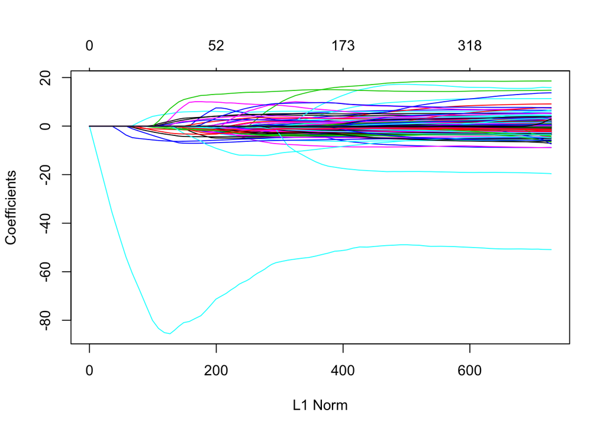

```r
data.model.mx <- as.matrix(data.model)

model.lasso = glmnet(x=data.model.mx[,1:ncol(data.model.mx)-1],y=data.model.mx[,ncol(data.model.mx)],alpha=1,nlambda=100,lambda.min.ratio=.0001)
plot(model.lasso)
```

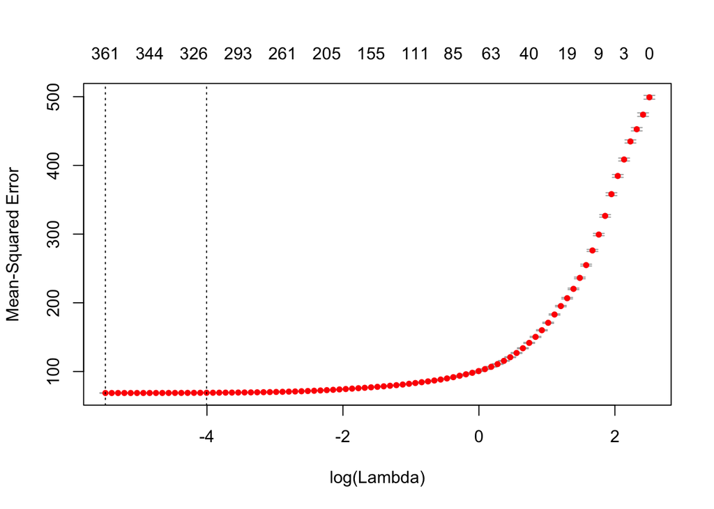

```r
model.cv.lasso <- cv.glmnet(x=data.model.mx[,1:ncol(data.model.mx)-1],y=data.model.mx[,ncol(data.model.mx)], alpha = 1)
plot(model.cv.lasso)
```

```r
(best.lamda = model.cv.lasso$lambda.min)
```

```
## [1] 0.004113154
```

```r
model.improved.lasso <- glmnet(x=data.model.mx[,1:ncol(data.model.mx)-1],y=data.model.mx[,ncol(data.model.mx)], lambda = best.lamda, alpha = 1, standardize = F)

lasso.pred=predict(model.improved.lasso,s=best.lamda,
                   newx=data.model.mx[,1:ncol(data.model.mx)-1])

lasso.betas.cols <- names(model.improved.lasso$beta[(which(!(model.improved.lasso$beta == 0))),])

vect.lasso.chars <- c("DevRatio (RSq)" = model.improved.lasso$dev.ratio, MSE = mean((lasso.pred - data.model.mx[,ncol(data.model.mx)])^2), num.pred = length(lasso.betas.cols))
mapply(format, vect.lasso.chars)
```

```
## DevRatio (RSq)            MSE       num.pred
##    "0.8632548"     "68.28793"          "322"
```

**Since we cannot calculate AIC from lasso model one way to get it is by removing the predictors corresponding to the coefficients which lasso removed and run a linear model with only the remaining predictors.**

```r
lin.model.lasso <- lm(reference ~ ., data = data.model[,c("reference", lasso.betas.cols)])
lasso.model.sm <- summary(lin.model.lasso)

lin.model.cols.lasso <- rbind(cbind(rownames(lasso.model.sm$coefficients[which(lasso.model.sm$coefficients[,4] <= 0.05), ][-1,])), "reference")

data.model.lasso <- data.model[, lin.model.cols.lasso]

lin.model.lasso.2 <- lm(reference ~ ., data = data.model.lasso)
lasso.model.sm.2 <- summary(lin.model.lasso.2)

vect.lasso.chars.2 <- c(AIC = AIC(lin.model.lasso.2), R.Sq = lasso.model.sm.2$r.squared, MSE = mean(lasso.model.sm.2$residuals^2), num.pred = ncol(data.model.lasso) - 1)

mapply(format, vect.lasso.chars.2)
```

```
##         AIC        R.Sq         MSE    num.pred
##    "378293" "0.8632885"   "68.2711"       "253"
```

### Regression Tree

**We fit regression tree from caret package with 10 fold cross validation.**

```r
ctrl <- trainControl(method = "cv", number = 10)

treeTrain <- train(reference~., method="rpart", data=data.model, tuneLength = 20, trControl = ctrl)
treeTrain$results
```

```
##             cp      RMSE  Rsquared       MAE    RMSESD  RsquaredSD
## 1  0.004383464  8.310988 0.8615385  5.105126 0.3199826 0.010963425
## 2  0.004665733  8.554397 0.8532812  5.335661 0.3494869 0.012149443
## 3  0.005137775  8.970337 0.8387951  5.742921 0.2895566 0.010308003
## 4  0.005160360  8.970337 0.8387951  5.742921 0.2895566 0.010308003
## 5  0.005514726  9.150312 0.8322279  5.882084 0.3184596 0.011641021
## 6  0.005918022  9.281760 0.8273585  5.938172 0.3317756 0.012376063
## 7  0.006482473  9.394860 0.8231751  6.035280 0.2792218 0.010808406
## 8  0.008317102  9.565754 0.8166553  6.162339 0.3223508 0.012486357
## 9  0.011379729  9.987488 0.8002381  6.662022 0.1937335 0.008596552
## 10 0.011473730 10.038632 0.7981885  6.766474 0.2104066 0.008874374
## 11 0.012902627 10.510557 0.7786571  7.181509 0.3317900 0.014218549
## 12 0.013797156 10.920774 0.7609440  7.479321 0.4082169 0.018209554
## 13 0.014332020 11.144666 0.7511341  7.649788 0.3609756 0.016237333
## 14 0.018001406 11.517581 0.7343309  7.972923 0.2301291 0.011340911
```

[output cut: 27 more lines]

```r
treeTrain$bestTune
```

```
##            cp
## 1 0.004383464
```

```r
treeTrain$finalModel
```

```
## n= 53500
##
## node), split, n, deviance, yval
##       * denotes terminal node
##
##   1) root 53500 26716880.000 47.02804
##     2) value18< -0.125 7407   174931.000 15.33410 *
##     3) value18>=-0.125 46093 17905930.000 52.12115
##       6) value378>=0.9039875 18261   824853.400 38.85077
##        12) value173< 0.305172 7595   164038.000 34.01536 *
##        13) value173>=0.305172 10666   356784.500 42.29395
##          26) value258>=0.9837325 4610    60384.740 38.37568 *
##          27) value258< 0.9837325 6056   171746.000 45.27665 *
##       7) value378< 0.9039875 27832 11755310.000 60.82806
##        14) value4< 0.70939 18752  6338440.000 53.54535
##          28) value118>=0.0221335 1873   159769.500 29.32963 *
##          29) value118< 0.0221335 16879  4958464.000 56.23248
##            58) value273>=0.8849515 2371   844478.700 40.66041
##             116) value173< 0.0086685 1696   366357.200 33.05356
##               232) value258< 0.533794 1476   127152.400 29.15217 *
##               233) value258>=0.533794 220    66013.330 59.22828 *
##             117) value173>=0.0086685 675   133403.600 59.77334 *
##            59) value273< 0.8849515 14508  3445082.000 58.77738
##             118) value103< 0.091584 11518  2551482.000 55.84385
##               236) value116< 0.913209 10826  1893779.000 54.41358
##                 472) value256>=0.8516865 618   175205.900 36.00074 *
##                 473) value256< 0.8516865 10208  1496366.000 55.52831
##                   946) value40>=0.293034 418   151268.700 37.14229 *
##                   947) value40< 0.293034 9790  1197761.000 56.31333 *
##               237) value116>=0.913209 692   289085.600 78.21973
##                 474) value136>=0.139738 73    12807.630 37.11766 *
##                 475) value136< 0.139738 619   138409.300 83.06699 *
##             119) value103>=0.091584 2990   412658.500 70.07781
##               238) value3< 0.7188185 2106   240370.300 65.68804 *
##               239) value3>=0.7188185 884    35022.940 80.53580 *
##        15) value4>=0.70939 9080  2368331.000 75.86829
##          30) value8>=0.058909 345    94951.380 32.43205 *
##          31) value8< 0.058909 8735  1596757.000 77.58386
##            62) value160>=0.0152675 2440   570181.100 66.94934
##             124) value348< -0.125 193     4028.955 28.70447 *
##             125) value348>=-0.125 2247   259609.900 70.23428 *
##            63) value160< 0.0152675 6295   643668.800 81.70590
##             126) value181>=0.043131 1307   141797.800 71.91532 *
##             127) value181< 0.043131 4988   343759.900 84.27132 *
```

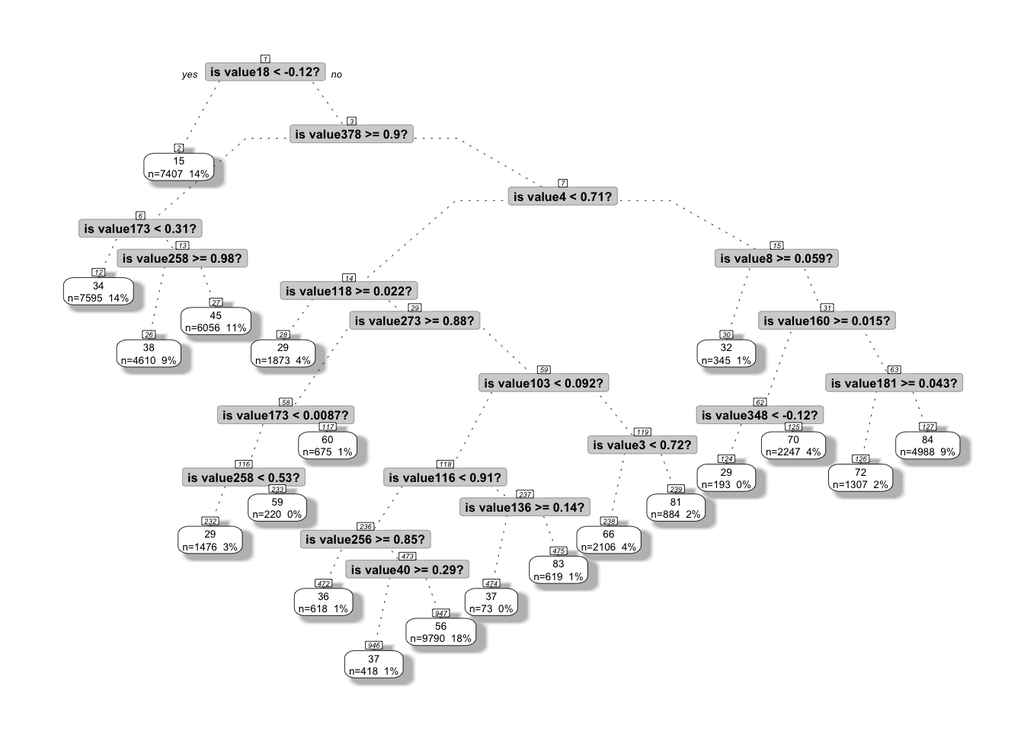

```r
prp(treeTrain$finalModel,extra=101, # display the number of observations that fall in the node
    branch=.5, # change angle of branch lines
    shadow.col="gray", # shadows under the leaves
    branch.lty=3, # draw branches using dotted lines
    split.cex=1.2, # make the split text larger than the node text
    split.prefix="is ", # put "is " before split text
    split.suffix="?", # put "?" after split text
    split.box.col="lightgray", # lightgray split boxes (default is white)
    split.border.col="darkgray", # darkgray border on split boxes
    split.round=.5,
    nn=TRUE) # display the node numbers, default is FALSE
```

```r
(treeTrain.MSE<-sum(residuals(treeTrain$finalModel)^2))
```

```
## [1] 3852432
```

```r
vect.caret.tree.chars <- c(R.Sq = treeTrain$results[which(treeTrain$results$cp == treeTrain$bestTune),]$Rsquared, MSE = sum(residuals(treeTrain$finalModel)^2), num.pred = length(predictors(treeTrain)))

mapply(format, vect.caret.tree.chars)
```

```
##        R.Sq         MSE    num.pred
## "0.8615385"   "3852432"        "95"
```

### Compare All Models

**Let’s compare the characteristics of fit of all the models.**

```r
#Linear Model
mapply(format, vect.lm.chars)
```

```
##         AIC        R.Sq         MSE    num.pred
##  "378103.3" "0.8638282"  "68.00158"       "264"
```

```r
#PCA Model
mapply(format, vect.chars.ordered.pca)
```

```
##            AIC           R.Sq            MSE       num.pred
##     "-3149517"            "1" "1.565849e-27"          "373"
```

```r
#Lasso Model
mapply(format, vect.lasso.chars)
```

```
## DevRatio (RSq)            MSE       num.pred
##    "0.8632548"     "68.28793"          "322"
```

```r
#Regression Tree Model
mapply(format, vect.caret.tree.chars)
```

```
##        R.Sq         MSE    num.pred
## "0.8615385"   "3852432"        "95"
```